# Data Camp / Intro to Time Series Analysis - Chapter 1

Initialize and load the data

```r
library(datasets)
data(AirPassangers)
```

Chapter 1 of [Data Camp - Intro to Time Series Analsys](https://www.datacamp.com/courses/introduction-to-time-series-analysis)

**Def**: A time series is a sequence of data in chronological order

`print()` prints the data with time stamps and includes the start, end and frequency informatino.

`plot()` plots a time series with time on the horizontal axis.

The course will cover basic time series models

- White Noise (WN)
- Random Walk (RW)
- Autoregression (AR)
- Simple Moving Average (MA)

### Examples

```r
data(Nile)

class(Nile)
```

```
## [1] "ts"
```

```r
str(Nile)
```

```
##  Time-Series [1:100] from 1871 to 1970: 1120 1160 963 1210 1160 1160 813 1230 1370 1140 ...
```

```r
print(Nile)
```

```
## Time Series:
## Start = 1871
## End = 1970
## Frequency = 1
##   [1] 1120 1160  963 1210 1160 1160  813 1230 1370 1140  995  935 1110  994
##  [15] 1020  960 1180  799  958 1140 1100 1210 1150 1250 1260 1220 1030 1100
##  [29]  774  840  874  694  940  833  701  916  692 1020 1050  969  831  726
##  [43]  456  824  702 1120 1100  832  764  821  768  845  864  862  698  845
##  [57]  744  796 1040  759  781  865  845  944  984  897  822 1010  771  676
##  [71]  649  846  812  742  801 1040  860  874  848  890  744  749  838 1050
##  [85]  918  986  797  923  975  815 1020  906  901 1170  912  746  919  718
##  [99]  714  740
```

```r
length(Nile)
```

```
## [1] 100
```

```r
head(Nile, n=5)
```

```
## Time Series:
## Start = 1871
## End = 1875
## Frequency = 1
## [1] 1120 1160  963 1210 1160
```

```r
tail(Nile, n=5)
```

```
## Time Series:
## Start = 1966
## End = 1970
## Frequency = 1
## [1] 746 919 718 714 740
```

The `plot()` function “knows” about time series and will plot them appropriately. Here are some examples

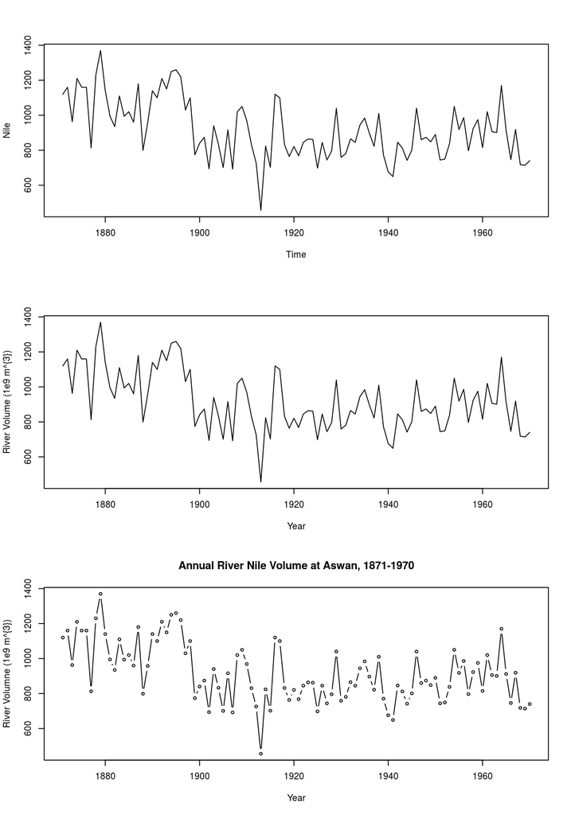

```r
par(mfrow=c(3, 1))

plot(Nile)
plot(Nile,
     xlab = "Year",
     ylab = "River Volume (1e9 m^{3})")

plot(Nile,
     xlab="Year",
     ylab="River Volumne (1e9 m^{3})",
     main="Annual River Nile Volume at Aswan, 1871-1970",
     type='b')
```

The **ts** version of `plot()` provides for a *y=* value which will be used as the “y” axis values.

When plotting a *Continuous time index* the points will not be evenly spaced, they will be spaced based on the *continuous* value. To addresss this, you can create a *discrete* index.

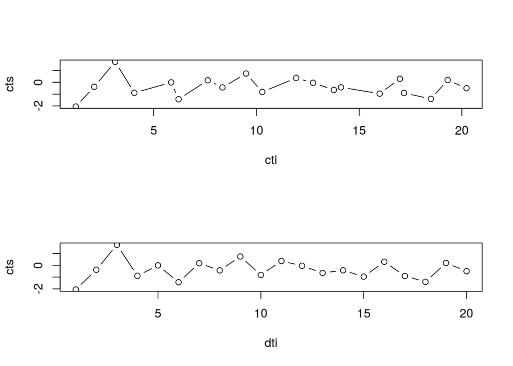

```r
cti = 1:20 + runif(20)
cts = c(rnorm(10), rnorm(10))
dti = 1:20

par(mfrow=c(2, 1))

plot(cti, cts, type='b')
plot(dti, cts, type='b')
```

### Sampling Frequency

Time series data can be equally spaced, such as hourly temperature measurements, or unevently spaced such as the temperature every time you check e-mail. Time series can also have *missing* values. For example, stocks are not traded on weekends, so there will be missing daily data for Saturdays and Sundays as well as possible holidays.

There are some *assumptions* made about a time series.

- Consecutive obs are equally spaced
- The have a discrete-time observation index
- This may hold *approximately* as in the case of stock trading with weekends and holidays missing.

- `start()`, which will return the start values, i.e. 1 1 may indicate it starts on hour 1 of day 1
- `end()`, returns the end values. i.e. 1 24 may indicate it ends on hour 24 of day 1
- `frequency()` returns the frequency, how many observations. i.e. 24
- `deltat()` returns the time interval duration. i.e. 0.0417 is 1/24 or hourly.
- `cycle()` returns the position of an obs in the cycle of each obs.

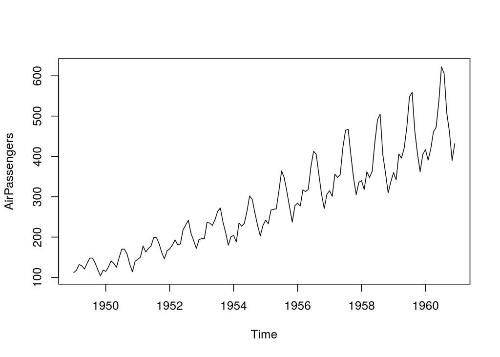

```r
plot(AirPassengers)
```

```r
print("Start")
```

```
## [1] "Start"
```

```r
start(AirPassengers)
```

```
## [1] 1949    1
```

```r
print("end")
```

```
## [1] "end"
```

```r
end(AirPassengers)
```

```
## [1] 1960   12
```

```r
print("time")
```

```
## [1] "time"
```

```r
time(AirPassengers)
```

```
##           Jan      Feb      Mar      Apr      May      Jun      Jul
## 1949 1949.000 1949.083 1949.167 1949.250 1949.333 1949.417 1949.500
## 1950 1950.000 1950.083 1950.167 1950.250 1950.333 1950.417 1950.500
## 1951 1951.000 1951.083 1951.167 1951.250 1951.333 1951.417 1951.500
## 1952 1952.000 1952.083 1952.167 1952.250 1952.333 1952.417 1952.500
## 1953 1953.000 1953.083 1953.167 1953.250 1953.333 1953.417 1953.500
## 1954 1954.000 1954.083 1954.167 1954.250 1954.333 1954.417 1954.500
## 1955 1955.000 1955.083 1955.167 1955.250 1955.333 1955.417 1955.500
## 1956 1956.000 1956.083 1956.167 1956.250 1956.333 1956.417 1956.500
## 1957 1957.000 1957.083 1957.167 1957.250 1957.333 1957.417 1957.500
## 1958 1958.000 1958.083 1958.167 1958.250 1958.333 1958.417 1958.500
## 1959 1959.000 1959.083 1959.167 1959.250 1959.333 1959.417 1959.500
## 1960 1960.000 1960.083 1960.167 1960.250 1960.333 1960.417 1960.500
##           Aug      Sep      Oct      Nov      Dec
## 1949 1949.583 1949.667 1949.750 1949.833 1949.917
## 1950 1950.583 1950.667 1950.750 1950.833 1950.917
## 1951 1951.583 1951.667 1951.750 1951.833 1951.917
## 1952 1952.583 1952.667 1952.750 1952.833 1952.917
## 1953 1953.583 1953.667 1953.750 1953.833 1953.917
## 1954 1954.583 1954.667 1954.750 1954.833 1954.917
## 1955 1955.583 1955.667 1955.750 1955.833 1955.917
## 1956 1956.583 1956.667 1956.750 1956.833 1956.917
## 1957 1957.583 1957.667 1957.750 1957.833 1957.917
## 1958 1958.583 1958.667 1958.750 1958.833 1958.917
## 1959 1959.583 1959.667 1959.750 1959.833 1959.917
## 1960 1960.583 1960.667 1960.750 1960.833 1960.917
```

```r
print("deltat")
```

```
## [1] "deltat"
```

```r
deltat(AirPassengers)
```

```
## [1] 0.08333333
```

```r
print("frequency")
```

```
## [1] "frequency"
```

```r
frequency(AirPassengers)
```

```
## [1] 12
```

```r
print("cycle")
```

```
## [1] "cycle"
```

```r
cycle(AirPassengers)
```

```
##      Jan Feb Mar Apr May Jun Jul Aug Sep Oct Nov Dec
## 1949   1   2   3   4   5   6   7   8   9  10  11  12
## 1950   1   2   3   4   5   6   7   8   9  10  11  12
## 1951   1   2   3   4   5   6   7   8   9  10  11  12
## 1952   1   2   3   4   5   6   7   8   9  10  11  12
## 1953   1   2   3   4   5   6   7   8   9  10  11  12
## 1954   1   2   3   4   5   6   7   8   9  10  11  12
## 1955   1   2   3   4   5   6   7   8   9  10  11  12
## 1956   1   2   3   4   5   6   7   8   9  10  11  12
## 1957   1   2   3   4   5   6   7   8   9  10  11  12
## 1958   1   2   3   4   5   6   7   8   9  10  11  12
## 1959   1   2   3   4   5   6   7   8   9  10  11  12
## 1960   1   2   3   4   5   6   7   8   9  10  11  12
```

### Missing values.

Missingness is represented by NA in R. There are many way’s to handle it and differnet functions in R handle it differently. Missing data can be removed or imputed (calculated) from the remaining data.

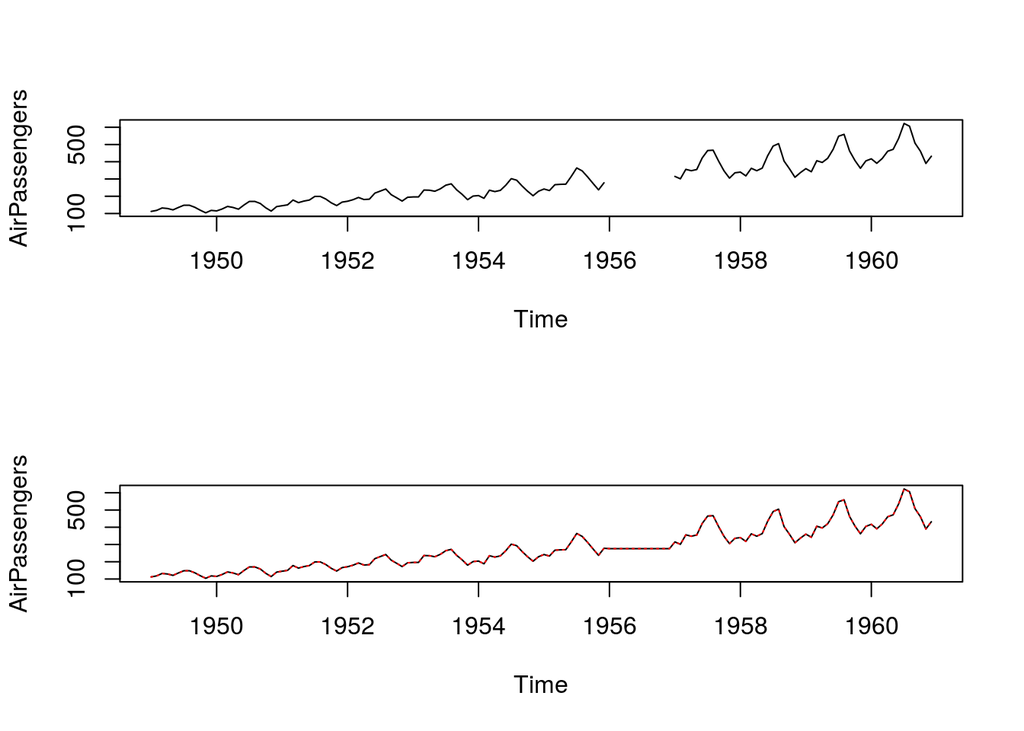

```r
data("AirPassengers")
AirPassengers[seq((7*12)+1, length.out=12)] <- NA  # NA out 19576

par(mfrow=c(2, 1))
plot(AirPassengers)

AirPassengers[85:96] <- mean(AirPassengers, na.rm = TRUE)

plot(AirPassengers)

data("AirPassengers")
points(AirPassengers, type = "l", col = 2, lty = 3)
```

### The **ts** class

To turn something into a time series use the `ts()` function.

```r
data_vector = rnorm(50)

head(data_vector)
```

```
## [1]  0.2132799 -1.2874050 -0.2896775 -0.7212702 -1.4044961 -0.3049528
```

```r
par(mfrow=c(2, 1))

plot(data_vector)

time_series = ts(data_vector, start=2004, frequency=4)   # start in 2004 with quarterly frequency

print(time_series)
```

```
##             Qtr1        Qtr2        Qtr3        Qtr4
## 2004  0.21327988 -1.28740503 -0.28967750 -0.72127020
## 2005 -1.40449614 -0.30495279 -0.59112746  0.87256828
## 2006  0.26846821 -0.58319224 -0.53182053  0.90398111
## 2007  1.16718841 -0.53775059  0.70865365  1.48471359
## 2008 -0.27043818 -0.27352045  0.24900163 -1.31572089
## 2009 -0.54066522 -0.89771351 -0.60199487  0.91132713
## 2010  0.08171836 -0.63120865  0.46379886 -1.42940084
## 2011  0.58744212  0.23571675 -1.41615671 -0.80094339
## 2012  0.08424580 -0.21655030 -0.02535267 -0.16207856
## 2013  0.25985827  0.99819066  0.92393182  1.27309061
## 2014  0.36000237 -0.88399904  0.62601765  0.75089099
## 2015 -0.91679077 -0.97624250  0.46558625  1.03841781
## 2016 -1.39754203  1.20357782
```

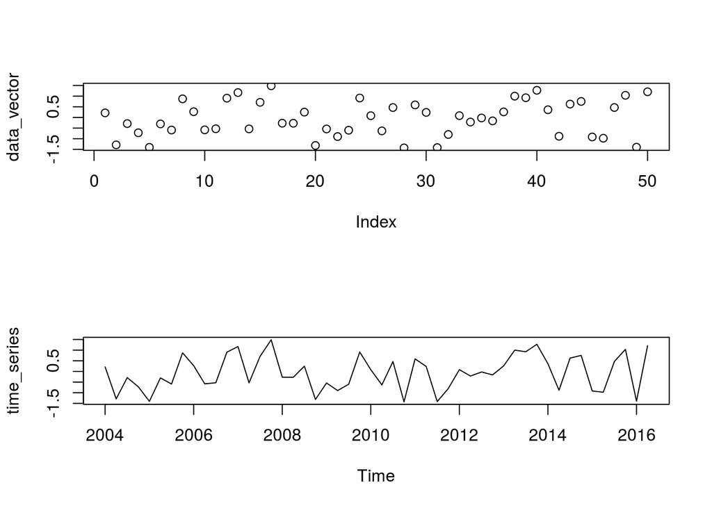

```r
plot(time_series)
```

### Check if it’s a *ts*

`is.ts()` returns TRUE if an object is a *ts* and FALSE if not.

```r
data("EuStockMarkets")

is.ts(EuStockMarkets)
```

```
## [1] TRUE
```

```r
start(EuStockMarkets)
```

```
## [1] 1991  130
```

```r
end(EuStockMarkets)
```

```
## [1] 1998  169
```

```r
frequency(EuStockMarkets)
```

```
## [1] 260
```

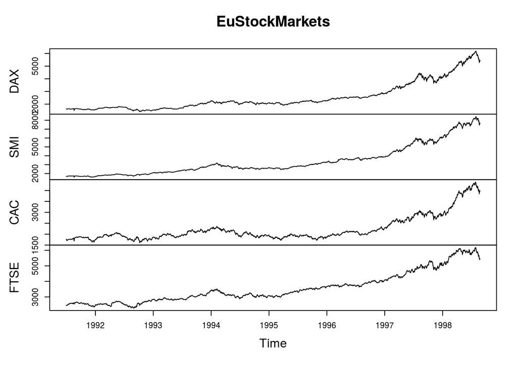

```r
plot(EuStockMarkets)
```

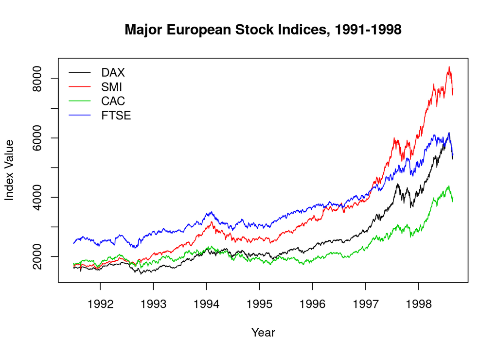

```r
ts.plot(EuStockMarkets, col = 1:4, xlab = "Year", ylab = "Index Value", main = "Major European Stock Indices, 1991-1998")
legend("topleft", colnames(EuStockMarkets), lty = 1, col = 1:4, bty = "n")
```